# Examples of using survextrap

Christopher Jackson chris.jackson@mrc-bsu.cam.ac.uk

2026-01-13

This vignette gives a quick tour of the features of the `survextrap` package, showing how to use it to fit a range of survival models. See the [cetuximab case study](https://chjackson.github.io/survextrap/articles/cetuximab.html) for a more in-depth demonstration of how it might be used in a typical health technology assessment.

See the [home page](https://chjackson.github.io/survextrap/) for the design principles of the package, and the methods vignette for technical details of the methods.

# Examples

For these examples, we use a dataset of trial of chemotherapy for colon cancer, provided as `colon` in the `survival` package, with an outcome of recurrence-free survival (`etype==1`), artificially censored at 3 years, and restricted to a random 20% subset. This is provided as `colons` in the `survextrap` package for convenience.

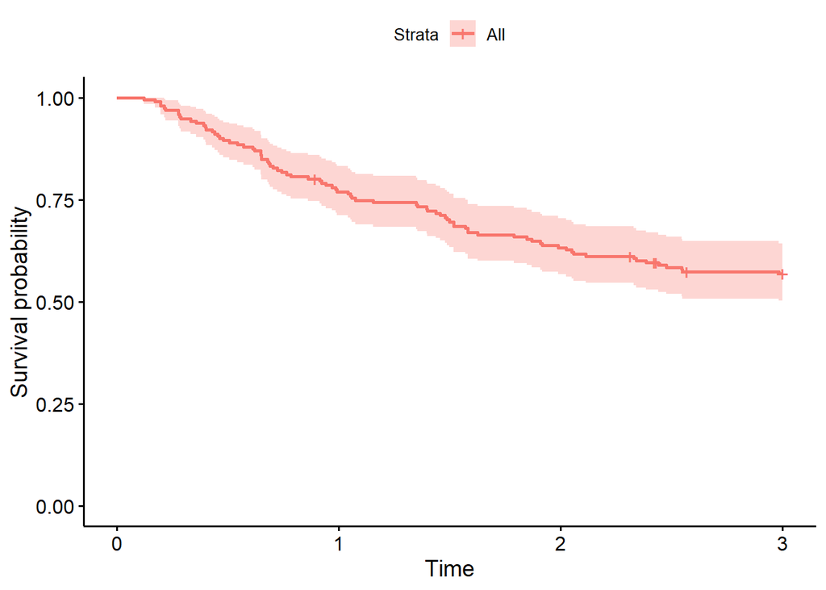

```r
library(survextrap)
library(ggplot2)
library(dplyr)
survminer::ggsurvplot(survfit(Surv(years, status) ~ 1, data=colons), data=colons)
```

## Simplest model: no external data

The following is the simplest, default model in the package fitted to the short-term trial data alone. No external data are supplied. After three years (the maximum follow up time of the short term data) the model assumes the hazard stays constant.

The plot shows the posterior median and 95% credible intervals for the survival and hazard functions. The spline adapts to give a practically perfect fit to the short-term data - note the Kaplan-Meier curve is obscured by the fitted posterior median. Although the model assumes the extrapolated hazard is constant, there is still a wide uncertainty interval around this constant value. This might be thought to be plausible.

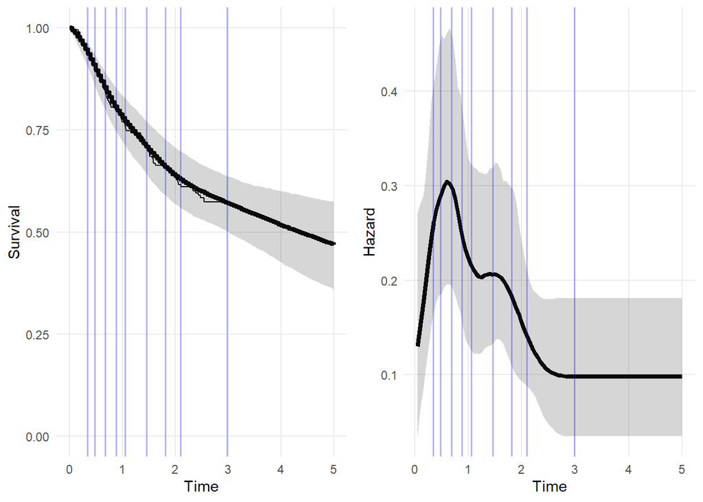

```r
nd_mod <- survextrap(Surv(years, status) ~ 1, data=colons, chains=1)
plot(nd_mod, show_knots=TRUE, tmax=5)
```

The spline knots are shown as blue lines. We could allow for the possibility of hazard changes beyond three years by placing spline knots beyond this point.

The `mspline` argument is used to control the spline. Here we create an additional knot outside the data, at 4 years.

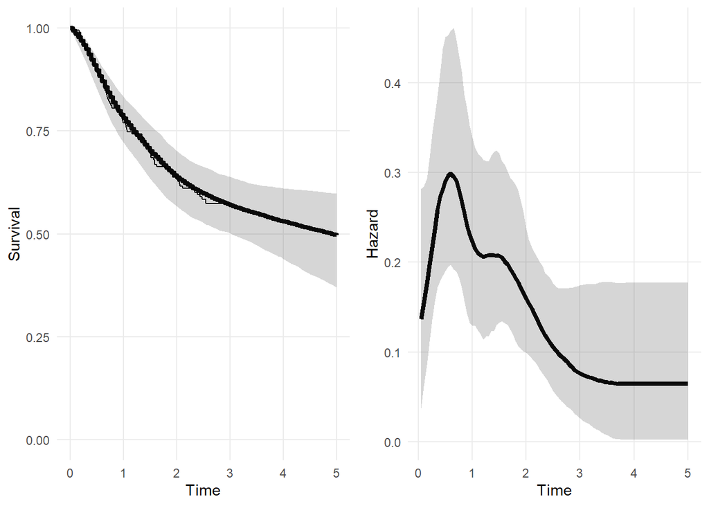

```r
nd_mod2 <- survextrap(Surv(years, status) ~ 1, data=colons, chains=1,
                      mspline = list(add_knots=4))
plot(nd_mod2, tmax=5)
```

This increases the amount of uncertainty about the extrapolated survival and hazard. The extrapolations are likely to be sensitive to the choice of any knots placed outside the data.

A sensible guide is to place the upper knot at the latest time that you are interested in modelling. Beyond this time, you either think the hazard will not change, or any changes in the hazard do not matter for the purpose of the model.

The priors should then be chosen to give a low probability that the hazard varies outside the range thought reasonable, e.g. in terms of orders of magnitude. The package should provide a nice way to convert beliefs of this kind into priors.

But note that it is only necessary to extrapolate in this way, using knots and default priors, if there is **no substantive information** about the long term hazard!

In many practical situations of extrapolation in time-to-event models, we do have information. For human survival, we at least know that people do not tend to live much longer than 100 years. There are usually data from national agencies about mortality of general populations.

The idea of the package is to make this external information as explicit as possible - ideally in the form of data.

### Note on model tuning

The `survextrap` function has various options which can be used to fine-tune the basic model explained in the Methods vignette. These options include the number of spline knots, the distribution on the coefficients ($p_i$), and the prior placed on the amount of smoothness in this curve $\sigma$.

It will not usually be necessary to tune these to obtain a model that gives a survival curve that fits the observed data well, hence to estimate the restricted mean survival time well. The choice of default settings in the package are informed by a simulation study [(Timmins et al.)](https://doi.org/10.48550/arXiv.2503.21388). However they may not be optimal in every case. See, for example, the cetuximab case study, where a tighter prior was placed on $\sigma$, and fewer knots were used.

Cross-validation can be used to determine whether tuning gives an overall improvement in fit to the observed data (see “Model comparison” below).

Note that the method to smooth the spline basis coefficients described in the [`survextrap` paper](https://doi.org/10.1186/s12874-023-02094-1) is no longer the default method, since version 0.9 of the package. The default is now a “random walk” model. The old method is available with `smooth_model="exchangeable"`, which here gives a less smooth and realistic-looking hazard curve, compared to the one above that was based on the random walk.

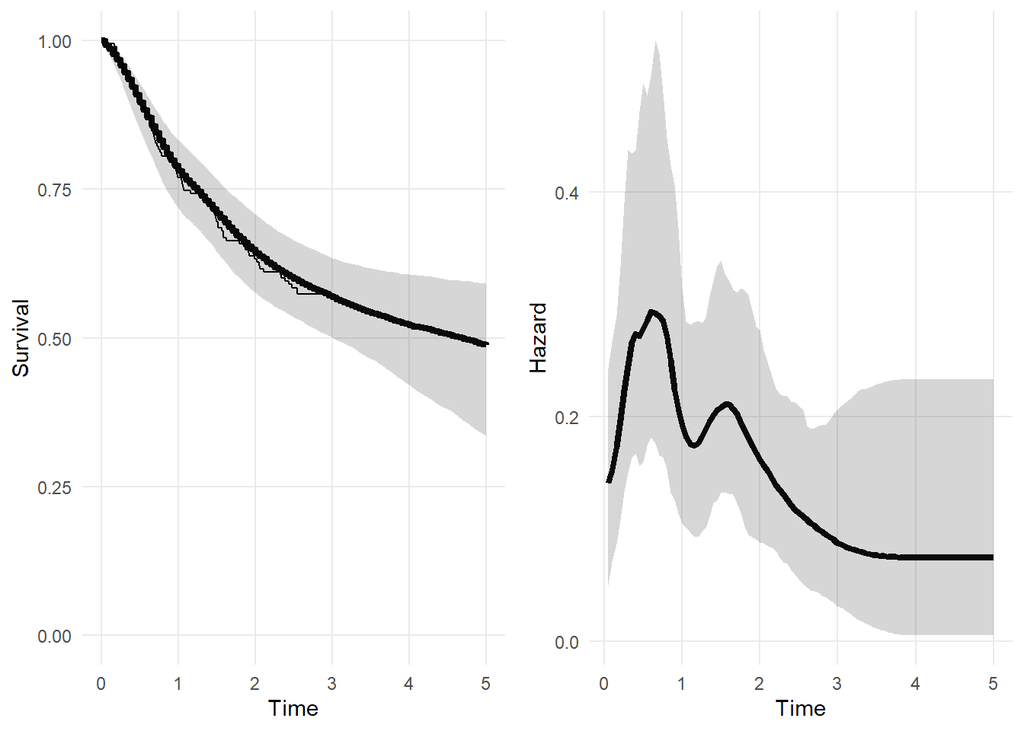

```r
nd_modr <- survextrap(Surv(years, status) ~ 1, data=colons, chains=1,
                      smooth_model = "exchangeable",
                      mspline = list(add_knots=4))
plot(nd_modr, tmax=5)
```

### Note on computation settings

Most of the example models in this vignette have been specified using computational approximations which allow the models to be fitted more quickly, but at the cost of some inaccuracy. This has been done so that the vignettes build more quickly. Specifically:

- `chains=1` was set in the examples above. This defines the number of chains used in the MCMC method to estimate the model. This option can be left out in practice - in which case, four MCMC chains are used, which is the default setting in the `rstan` engine that the package uses, and is more reliable in practice. The number of iterations per chain can also be set with the `iter` argument, among other settings, see `stan()`.
- Other models in this vignette are fitted using `fit.method="opt"`. This uses an [approximation to the posterior](https://mc-stan.org/rstan/reference/stanmodel-method-optimizing.html). This is OK for producing point estimates of the parameters (the posterior mode is used - note this is likely to differ from the mean or median) but the uncertainty will be only roughly approximated. This is very useful for quick checks and model development.
- If using MCMC, make sure to check the diagnostics to ensure that the fit has *converged* - the values of `rhat` in the summary output (e.g. below) should not be more than 1.05 for each parameter ([see here](https://mc-stan.org/rstan/reference/Rhat.html) for technical details).

```r
head(summary(nd_mod))
```

```
## # A tibble: 6 × 8
##   variable basis_num  median    lower   upper     sd  rhat ess_bulk
##   <chr>        <dbl>   <dbl>    <dbl>   <dbl>  <dbl> <dbl>    <dbl>
## 1 alpha           NA -0.562  -0.783   -0.349  0.111  1.00      618.
## 2 coefs            1  0.0168  0.00198  0.0401 0.0103 1.01      145.
## 3 coefs            2  0.0300  0.00584  0.0595 0.0142 1.00      271.
## 4 coefs            3  0.0702  0.0328   0.145  0.0269 1.00     1086.
## 5 coefs            4  0.112   0.0633   0.199  0.0346 0.999     893.
## 6 coefs            5  0.0949  0.0516   0.167  0.0298 0.999     881.
```

#### Divergent transitions

- If using MCMC, there may be a warning produced by Stan about `divergent transitions after warmup`. This is a limitation of the sampling algorithm, and can happen when the posterior distribution is awkward to sample from. See the [Stan documentation](https://mc-stan.org/learn-stan/diagnostics-warnings.html) for technical details. If there are only one or two divergent transitions, the message is probably safe to ignore, but in any case the results should be examined to ensure they make sense. With lots of divergent transitions, it is safer to simplify the model, e.g. by using stronger priors or fewer spline knots.

## Restricted mean survival

The function `rmst` calculates the restricted mean survival time (RMST) from a fitted model. Uncertainty is expressed by using the MCMC sample of the model parameters, and calculating the mean (or RMST) for each draw, which produces a sample from the posterior distribution. The posterior median and credible intervals are computed by summarising this sample.

Here we compute the restricted mean survival time $RMST(t)$ over three alternative time limits $t$: 3, 10 and 1000 years. The upper 95% credible limit for $RMST(1000)$ is very large.

> **Note**: `niter` controls how many iterations of the MCMC sample (previously drawn by `survextrap`) should be used to summarise the distribution. This is artificially set to a small number in this example so that it runs faster. This is OK for quick checks, but in practice for “final results”, you should check there are enough iterations to get summaries with the amount of precision you want, which will usually be 1000 or more.

```r
rmst(nd_mod2, t = c(3,10,1000), niter=100)
```

```
## # A tibble: 3 × 5
##   variable     t median lower  upper
##   <chr>    <dbl>  <dbl> <dbl>  <dbl>
## 1 rmst         3   2.21  2.03   2.35
## 2 rmst        10   5.38  4.45   6.34
## 3 rmst      1000  12.0   5.35 124.
```

We do not really believe that the mean survival for this population can be this large. This is evidence that the fitted model is unrealistic, and we should have included external information to bound the estimates of the mean within plausible values. This can be done with external data.

> **Note** also the `mean` function can be used to get the mean survival time over an infinite time horizon. In practice, this is sometimes numerically unstable, resulting in an error message about a divergent integral. That would suggest that there is a substantial posterior probability that the mean is infinite. This is often a consequence of having not enough data to inform survival over an infinite horizon.

## Custom posterior summaries

The `summ_fns` argument can be used to specify any custom summaries of the posterior distribution of quantities in `survextrap` models. For example, to use the mean, median and interquartile range, rather than the median and 95% credible interval:

```r
rmst(nd_mod2, t = c(3,10,1000),
     summ_fns = list(mean=mean, median=median,
                     ~quantile(.x, c(0.25, 0.75))),
     niter=50)
```

```
## # A tibble: 3 × 6
##   variable     t  mean median `25%` `75%`
##   <chr>    <dbl> <dbl>  <dbl> <dbl> <dbl>
## 1 rmst         3  2.19   2.21  2.13  2.24
## 2 rmst        10  5.25   5.29  4.97  5.55
## 3 rmst      1000 15.3   10.0   7.42 16.9
```

## Extrapolation using long term population data

Suppose we judge that after 5 years, the survival of these patients will be the same as in the general population, and we have some data describing the annual survival rates of a population who are similar to this one, perhaps from matching to national statistics or registry data by age and sex. We would construct it something like this (though fake data are shown here).

```r
extdat <- data.frame(start = c(5, 10, 15, 20),
                     stop =  c(10, 15, 20, 25),
                     n = c(100, 100, 100, 100),
                     r = c(50, 40, 30, 20))
```

This is passed as the `external` argument to `survextrap`. Extra knots are added at 10 and 25 years, to allow for the possibility that the hazard function will change shape during the times covered by the external data. The external data are coarser than the individual data, and it would be impossible to identify complex hazard variations from them, so there is no point in using more than a couple of extra knots. If there is a concern that this knot choice may influence the results, then sensitivity analysis is advised.

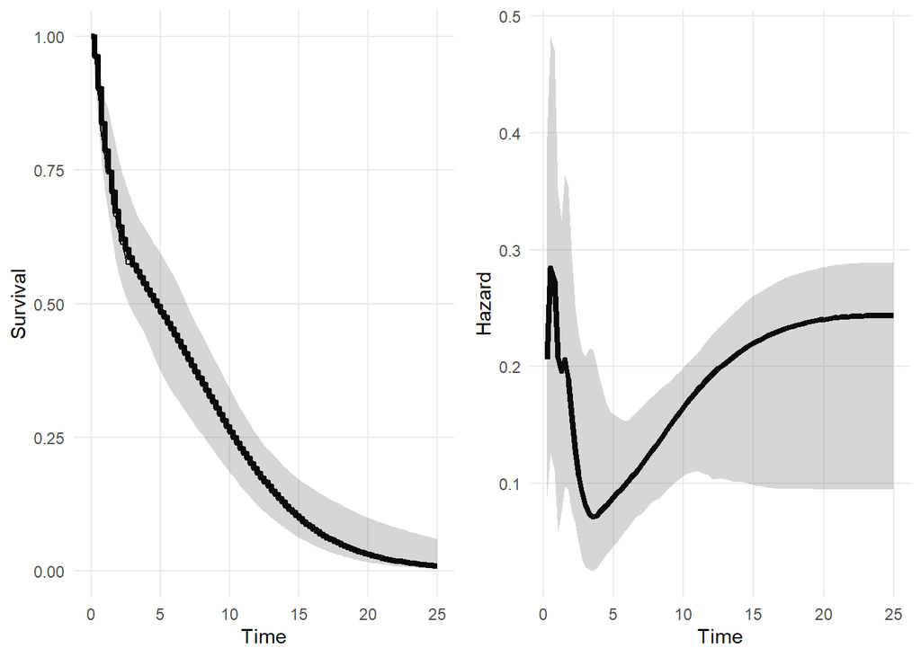

```r
nde_mod <- survextrap(Surv(years, status) ~ 1, data=colons,
                      fit_method="opt", external = extdat,
                      mspline = list(add_knots=c(4, 10, 25)))
plot(nde_mod)
```

```r
mean(nde_mod, niter=100)
```

```
## # A tibble: 1 × 4
##   variable median lower upper
##   <chr>     <dbl> <dbl> <dbl>
## 1 mean       6.35  5.21  8.10
```

```r
rmst(nde_mod, c(3, 10, 1000), niter=100)
```

```
## # A tibble: 3 × 5
##   variable     t median lower upper
##   <chr>    <dbl>  <dbl> <dbl> <dbl>
## 1 rmst         3   2.20  2.00  2.44
## 2 rmst        10   5.13  4.34  5.93
## 3 rmst      1000   6.34  5.21  8.09
```

Including the external data gives a more confident extrapolation. The mean is finite. RMST converges to the mean, as it is supposed to.

### Modelling differences between the trial and external data

The external data need not be from an identical population to one of the arms of the trial data. If we can assume that the datasets are related through a model, we can perform extrapolations under the assumptions of that model.

A simple example is where the hazards are assumed to be proportional between the trial and external data. To implement this, we could define a binary factor covariate called `dataset` to identify each of the two datasets.

```r
levs <- c("trial", "external")
colons$dataset <- factor("trial", level=levs)
extdat$dataset <- factor("external", level=levs)
```

A proportional hazards model is defined by including this covariate on the right hand side of the model formula in the `survextrap` command. (See Covariates below for more about models with covariates).

```r
ndec_mod <- survextrap(Surv(years, status) ~ dataset, data=colons,
                      external = extdat,
                      fit_method = "opt",
                      mspline = list(add_knots=c(4, 10, 25)))
```

The effect of this covariate then describes the hazard ratio for the external data compared to the trial data - in this artificial example, no difference between the datasets is discernible.

```r
summary(ndec_mod) %>% filter(variable=="hr")
```

```
## # A tibble: 1 × 10
##   variable basis_num term          mode median  lower upper    sd  rhat ess_bulk
##   <chr>        <dbl> <chr>        <dbl>  <dbl>  <dbl> <dbl> <dbl> <dbl>    <dbl>
## 1 hr              NA datasetexte…  2.23   2.33 0.0440  117.  87.6 1.000    2096.
```

Different predictions are now available for the trial and external population, so in decision-making contexts you would need to consider which is more relevant.

```r
rmst(ndec_mod, t=3, niter=100)
```

```
## # A tibble: 2 × 6
##   variable dataset      t median lower upper
##   <chr>    <chr>    <dbl>  <dbl> <dbl> <dbl>
## 1 rmst     trial        3   2.34 2.08   2.96
## 2 rmst     external     3   1.70 0.156  3.00
```

If there are more covariates observed in the datasets, these might be added to the model to explain any differences between the datasets. Though caution is required as always when extrapolating outside the data, to different populations as well as over time. To extrapolate we would need to assume that all parameter estimates are valid outside the data that they were estimated from.

## Expert elicitation on the long term

Information about long term survival could be elicited from experts. To use this information about the model, we should also elicit the expert’s *uncertainty*.

For example, we ask the expert to consider a set of people who have survived for 10 years. How many of them would they expect to survive a further 5 years? Through some kind of formal elicitation process, they supply a best guess (median) of 30%, and a 95% credible interval of 10% to 50%.

Using standard techniques from elicitation ([SHELF](https://shelf.sites.sheffield.ac.uk)) we can interpret that as a $Beta(6.6, 15.0)$ prior distribution for the survival probability.

```r
SHELF::fitdist(vals=c(0.1, 0.3, 0.5), probs=c(0.025, 0.5, 0.975),
               lower=0, upper=1)$Beta
```

```
##     shape1   shape2
## 1 6.588104 14.96673
```

We can interpret this as the posterior from having observed $y=6$ survivors out of $n=20$ people (recalling the posterior from a $Binomial(y, n)$ combined with a vague $Beta(0.5, 0.5)$ prior is $Beta(y+0.5, n-y+0.5)$, and rounding $n$ and $y$ to whole numbers).

So the expert’s judgement is equivalent to the information in an external dataset of the form:

| Follow-up period |  | Number |  |
| --- | --- | --- | --- |
| Start time $t$ | End time $u$ | Alive at $t$ | Still alive at $u$ |
| 10 | 15 | 20 | 6 |

and we can use it in a `survextrap` model as follows:

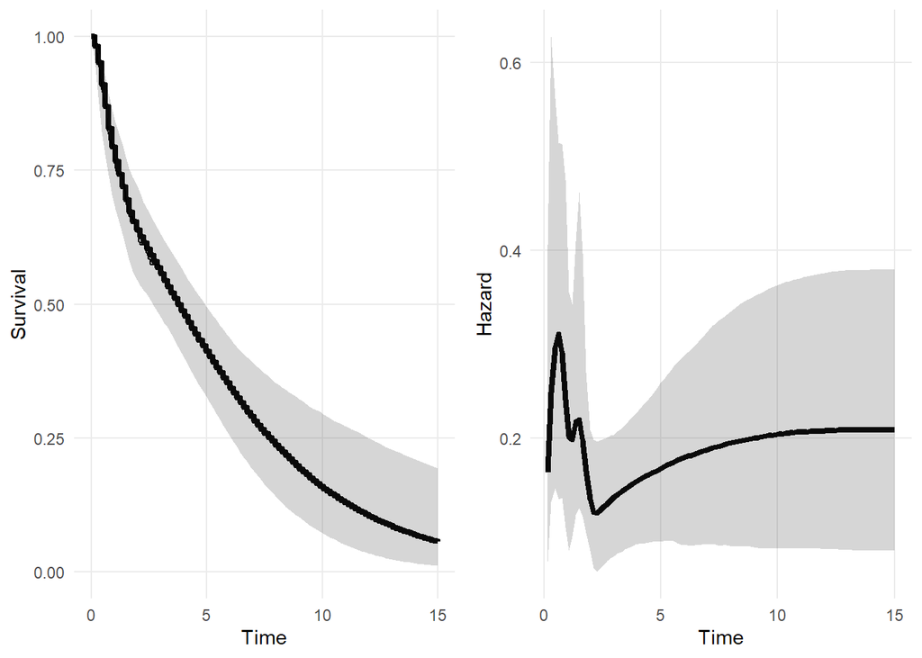

```r
extdat <- data.frame(start = c(10), stop =  c(15),
                     n = c(20), r = c(6))
nde_mod <- survextrap(Surv(years, status) ~ 1, data=colons,
                      external = extdat, fit_method="opt")
plot(nde_mod)
```

```r
mean(nde_mod, niter = 100)
```

```
## # A tibble: 1 × 4
##   variable median lower upper
##   <chr>     <dbl> <dbl> <dbl>
## 1 mean       5.20  3.94  9.89
```

This approach might be extended to include elicited values from multiple time points, or considering multiple experts. In each case the elicited information can be converted straightforwardly into an aggregate table for use in `survextrap`.

## Covariates

`survextrap` uses a proportional hazards model to represent covariates by default. In the example here, we model survival by treatment group `rx`, which is a factor with three levels. First fit a standard Cox model:

```r
coxph(Surv(years, status) ~ rx, data=colons)
```

```
## Call:
## coxph(formula = Surv(years, status) ~ rx, data = colons)
##
##              coef exp(coef) se(coef)      z      p
## rxLev     -0.3919    0.6758   0.2597 -1.509 0.1313
## rxLev+5FU -0.6740    0.5097   0.2800 -2.407 0.0161
##
## Likelihood ratio test=6.39  on 2 df, p=0.04088
## n= 191, number of events= 82
```

Then fit a `survextrap` model and extract the log hazard ratios. These agree with the Cox model - as expected, as we are using a proportional hazards model with a very flexible baseline hazard function.

```r
rxph_mod <- survextrap(Surv(years, status) ~ rx, data=colons, refresh=0, fit_method="opt")
summary(rxph_mod) |>
    filter(variable=="loghr")
```

```
## # A tibble: 2 × 10
##   variable basis_num term        mode median  lower  upper    sd  rhat ess_bulk
##   <chr>        <dbl> <chr>      <dbl>  <dbl>  <dbl>  <dbl> <dbl> <dbl>    <dbl>
## 1 loghr           NA rxLev     -0.384 -0.399 -0.908  0.109 0.259 1.000    1983.
## 2 loghr           NA rxLev+5FU -0.664 -0.668 -1.21  -0.132 0.281 1.00     1875.
```

The posterior median survival curves (thick lines) agree with the subgroup-specific Kaplan-Meier estimates (thin lines).

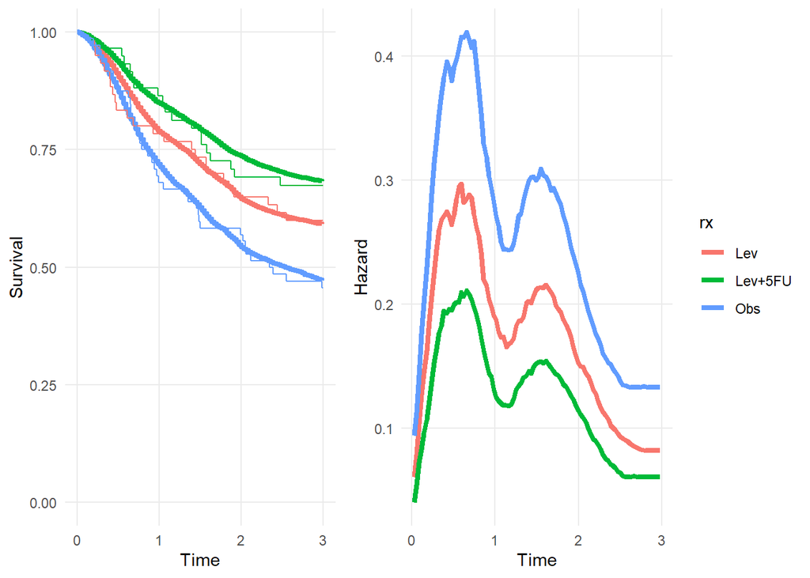

```r
plot(rxph_mod, niter=100)
```

Any number of covariates, categorical or continuous, can be included.

We can also have covariates in the external data. If covariates are included in the model formula, and an external dataset is supplied, then we must specify covariate values for each row of the external dataset. (If the covariates are factors, then they can be supplied as character vectors in `external`, but the values should be taken from the factor levels in the internal data [todo: this probably isn’t a necessary restriction])

For example, the external data might be assumed to have the same survival as the control group of the trial (corresponding to a value of `"Obs"` for the variable `rx`).

```r
extdat <- data.frame(start = c(5, 10), stop =  c(10, 15),
                     n = c(100, 100), r = c(50, 40),
                     rx = "Obs")
rxphe_mod <- survextrap(Surv(years, status) ~ rx, data=colons,
                      external = extdat, refresh=0, fit_method="opt")
rmst(rxphe_mod, niter=100, t=20)
```

```
## # A tibble: 3 × 6
##   variable rx          t median lower upper
##   <chr>    <chr>   <dbl>  <dbl> <dbl> <dbl>
## 1 rmst     Obs        20   4.81  3.79  5.99
## 2 rmst     Lev        20   6.72  4.79  9.77
## 3 rmst     Lev+5FU    20   8.82  5.96 11.5
```

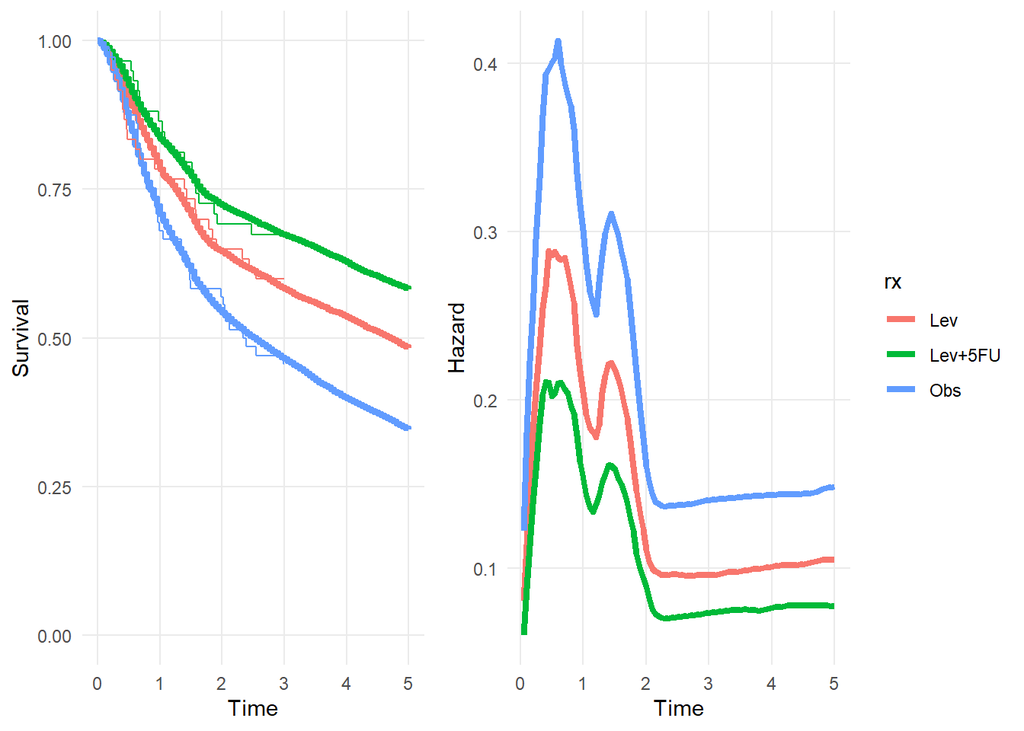

```r
plot(rxphe_mod, niter=100, tmax=5)
```

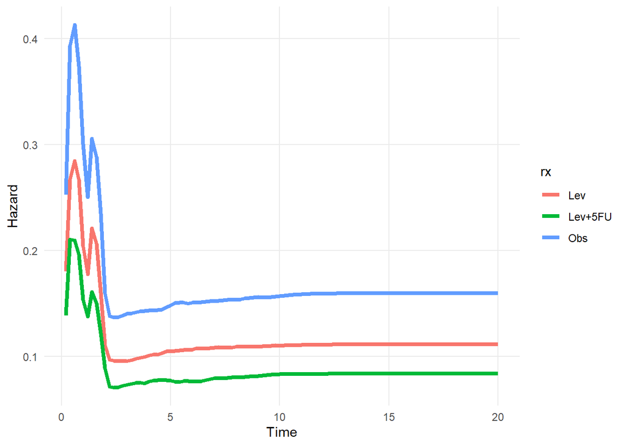

```r
plot_hazard(rxphe_mod, niter=100, tmax=20)
```

### Covariate-specific outputs

After fitting a model that includes covariates, to present covariate-specific outputs, a `newdata` data frame is supplied to output functions such as `rmst()`, `survival()` or `hazard()`. This contains one row for each different covariate value (or combination of covariate values) for which outputs are required, in this case, the Observation and Lev+5FU treatment groups.

```r
nd <- data.frame(rx = c("Obs","Lev+5FU"))
survival(rxph_mod, t=c(5,10), newdata=nd)
```

```
## # A tibble: 4 × 6
##   variable rx          t median  lower upper
##   <chr>    <chr>   <dbl>  <dbl>  <dbl> <dbl>
## 1 survival Obs         5  0.364 0.214  0.504
## 2 survival Obs        10  0.202 0.0489 0.405
## 3 survival Lev+5FU     5  0.596 0.408  0.731
## 4 survival Lev+5FU    10  0.443 0.181  0.652
```

### Standardised outputs

In models with covariates, “standardised” outputs are defined by averaging, or marginalising, over covariate values in some reference population, rather than being conditional on a given covariate value. To compute these, we first construct a data frame with one row for each member of the reference population, and columns for the covariate values. We then tell the output function to average the outputs over this reference population, by applying the `standardise_to` function to the population, and supplying the result as the `newdata` argument.

```r
ref_pop <- data.frame(rx = c("Obs","Lev+5FU"))
survival(rxph_mod, t = c(5,10), newdata = standardise_to(ref_pop))
```

```
## # A tibble: 2 × 5
##   variable     t median  lower upper
##   <chr>    <dbl>  <dbl>  <dbl> <dbl>
## 1 survival     5  0.464 0.239  0.713
## 2 survival    10  0.311 0.0655 0.621
```

Here a reference population is defined that consists of 1 person in the Observation treatment group and 1 person in the Lev+5FU group. As expected, the marginal 5 and 10 year survival probabilities for this population are about half way between the treatment-specific estimates for these survival probabilities.

#### Notes on computation of standardised outputs

Only the *distribution* of covariate values in the reference population matters, and not the population *size*. For example, the same result would have been obtained here from a reference population with $n$ people in every treatment group, for any $n$.

If the reference population is larger, then computation will be slower. The default procedure involves concatenating multiple MCMC samples of $R$ parameter values into one:

$$(\theta^{(1)} |
\mathbf{x}_1,...,\theta^{(R)}|\mathbf{x}_1), ..., (\theta^{(1)} |
\mathbf{x}_M,...,\theta^{(R)}|\mathbf{x}_M)$$

where $R$ is the number of MCMC samples obtained in the original `survextrap` fit (4000 with the current default number of chains and iterations used by `rstan`), $M$ is the size of the reference population, and $\mathbf{x}_j$ is the vector of covariate values for the $j$th member of the reference population. The output function is then evaluated for each element of this concatenated sample, to obtain a sample of size $R \times M$ from the posterior of the standardised output. If this sample is large, this may be computationally intensive, particularly if the output function is slow to evaluate (e.g. the RMST, which uses numerical integration).

In the example above, there was only one covariate, which was categorical, and we just wanted a 50/50 balance of two groups. Therefore a reference population of size 2 was sufficient to describe the distribution of covariates. In more complex situations, e.g. with continuous covariates, we might want a larger reference population to characterise the distribution.

To save computation for standardised outputs with large reference populations, an alternative computational method is available. This works by drawing a random covariate value $\mathbf{x}_r$ from the reference population for each MCMC iteration $r$, and then evaluating the output function for the corresponding parameter value $\theta^{(r)} | \mathbf{x}_r$. The resulting sample of outputs is then a sample of size $R$ from the posterior of the standardised output:

$$(\theta^{(1)} |
\mathbf{x}_1,...,\theta^{(R)}|\mathbf{x}_R)$$

This alternative method is invoked by setting the `random=TRUE` argument to `standardise_to`, e.g.

```r
survival(rxph_mod, t = c(5,10), newdata = standardise_to(ref_pop, random=TRUE))
```

[output not shown]

The results will then be dependent on the random number seed, so care should be taken that enough MCMC iterations have been run in the original `survextrap` call that the output is stable to the required number of significant figures.

#### Time-dependent standardised outputs

Note that if computing a marginal quantity for multiple times, such as the hazard function, care should be taken to define an appropriate standardising population, which may change over time. For example, the [`standsurv`](https://CRAN.R-project.org/package=flexsurv/vignettes/standsurv.html) function in the `flexsurv` package computes a marginal hazard function for a reference population via weighting covariate-specific hazard functions by the survival probability. In effect, the standardising population changes over time to account for different subgroups having different survival. To achieve this in `survextrap`, `hazard()` must be called once for each time, with a different standardising population at each time representing the expected survivors, though these populations must currently be constructed by hand.

### Non-proportional hazards model

The flexible non-proportional hazards model described in the methods vignette can be specified with the `nonprop` argument. `nonprop=TRUE` gives all covariates in the main model formula non-proportional hazards. A subset of covariates can be given non-proportional hazards by passing a different model formula as the `nonprop` argument.

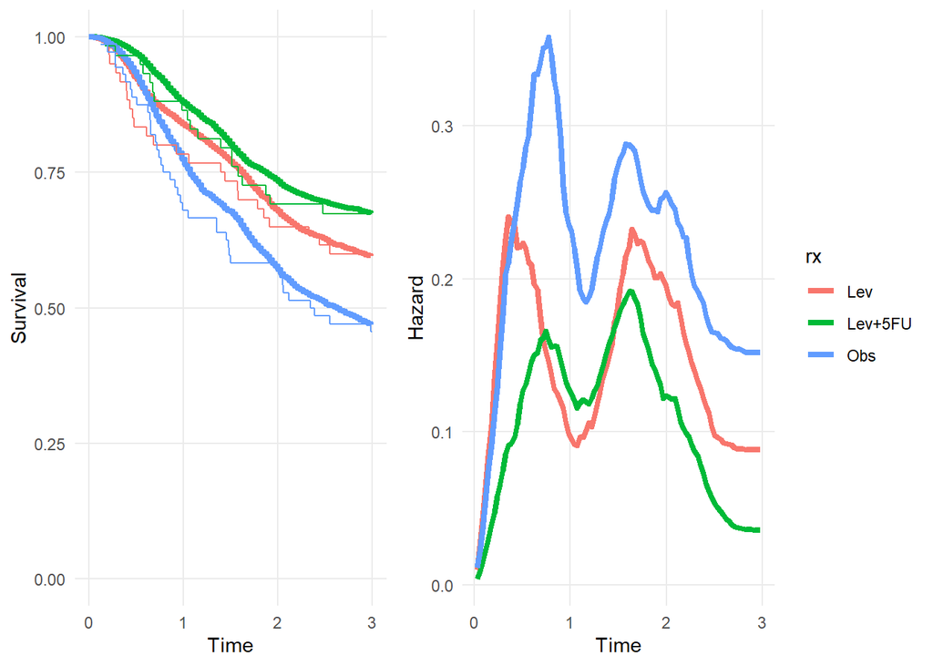

```r
rxnph_mod <- survextrap(Surv(years, status) ~ rx, data=colons, nonprop=TRUE, fit_method="opt")
plot(rxnph_mod, niter=200)
```

Note the non-constant separation between the posterior median hazard curves from the three treatment groups.

In this example, the sample size in each treatment group and time period is small, so this model is probably overfitted. While the posterior median survival seems to fit poorly to the Kaplan-Meier estimates in some regions, there is large uncertainty around these estimates that isn’t shown in these plots.

The non-proportional hazards model can be “tuned” by changing the number of spline basis terms and the knot positions (through the `mspline` argument to `survextrap`), or by changing the prior on the parameter $\sigma^{(np)}_s$ that controls the smoothness of the departures from proportional hazards (`prior_sdnp` argument). A limitation of this model (compared to the Royston and Parmar spline model) is that there is a common set of knot positions governing the flexibility of the baseline hazard and the flexibility of covariate effects, however different levels of flexibility can still be achieved (to some extent) through tuning priors on the different smoothness parameters.

If a plot of the posterior hazard ratio against time is desired, this might be constructed by extracting samples from the posterior of the hazard for different covariate values by using `hazard(..., sample=TRUE)`, converting to samples from the hazard ratio, and then summarising and plotting.

The functions `hazard_ratio()` and `plot_hazard_ratio()` can be used to calculate or plot the ratio of hazards between two covariate values, as a function of time. The covariate values are supplied in a data frame with two rows - all covariates in the model should be included here (there is currently no facility for standardised effect estimation in these functions).

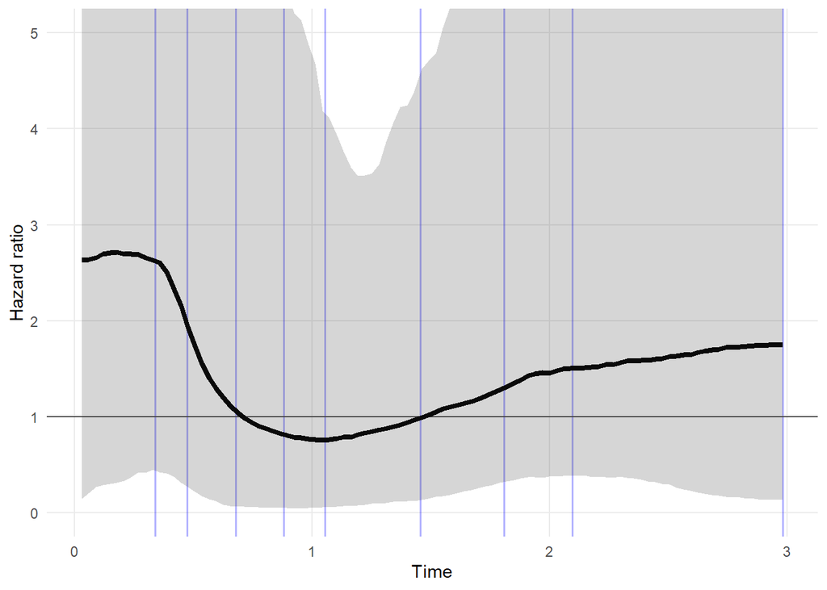

```r
nd <- data.frame(rx = c("Lev+5FU","Lev"))
plot_hazard_ratio(rxnph_mod, newdata=nd) +
  coord_cartesian(ylim=c(0,5))
```

In this example, the credible interval for the Lev+5FU / Lev hazard ratio is wide, and does not suggest that the hazard ratio is time-varying. This model may be overfitted around time 0.5 to 1 - fewer knots may be preferable if this model is intended for description of hazard trajectories.

### Treatment effect waning models

These are described in [the methods vignette](https://chjackson.github.io/survextrap/articles/methods.html#waning).

## Model comparison

The leave-one-out cross-validation method of the [`loo`](https://mc-stan.org/loo/) package is automatically implemented for every model fitted with `survextrap`, unless `survextrap(..., loo=FALSE)` is used.

The cross-validation results are returned in the `loo` and `loo_external` component of the fitted model object, describing the fit of the model to the individual and external data respectively. For the external data, “leave one out” refers to leaving out a single individual’s outcome from the aggregate totals.

See [the loo vignette](https://mc-stan.org/loo/articles/loo2-example.html) for some information about how to interpret these.

Roughly, lower values of the `looic` statistic indicate models with better predictive ability.

These cross validation statistics can only be computed if the models are fitted with MCMC. The models above were fitted with the posterior mode optimisation method (`fit_method="opt"`), so that this vignette runs quickly. If we had used MCMC, we could compare the proportional hazards model with the non-proportional hazards model:

```r
rxph_mod$loo
```

```r
rxnph_mod$loo
```

We should find that `looic` is lower for the proportional hazards model, suggesting that the non-proportional hazards model is worse for prediction. It is likely to be excessively complicated for the data.

If the warning message `"Some Pareto k diagnostic values are too high"` appears after calling `survextrap`, it was produced by the `loo` package. The fitted model is still valid, but the cross-validation statistics may not be. See [the loo vignette](https://mc-stan.org/loo/articles/loo2-example.html) and the references from there for more explanation. This happens for the non-proportional hazards model here - cross-validation failed for 2 out of the 191 observations in the data.

## Cure models

The package provides a simulated dataset `curedata` with an obvious cure fraction. Here we fit the cure models that are described in the methods vignette.

The probability of cure for `x=0` is 0.5, and for `x=1` 0.622 (so the log odds ratio is 0.5). The uncured fraction follows a Weibull(1.5, 1.2) survival distribution.

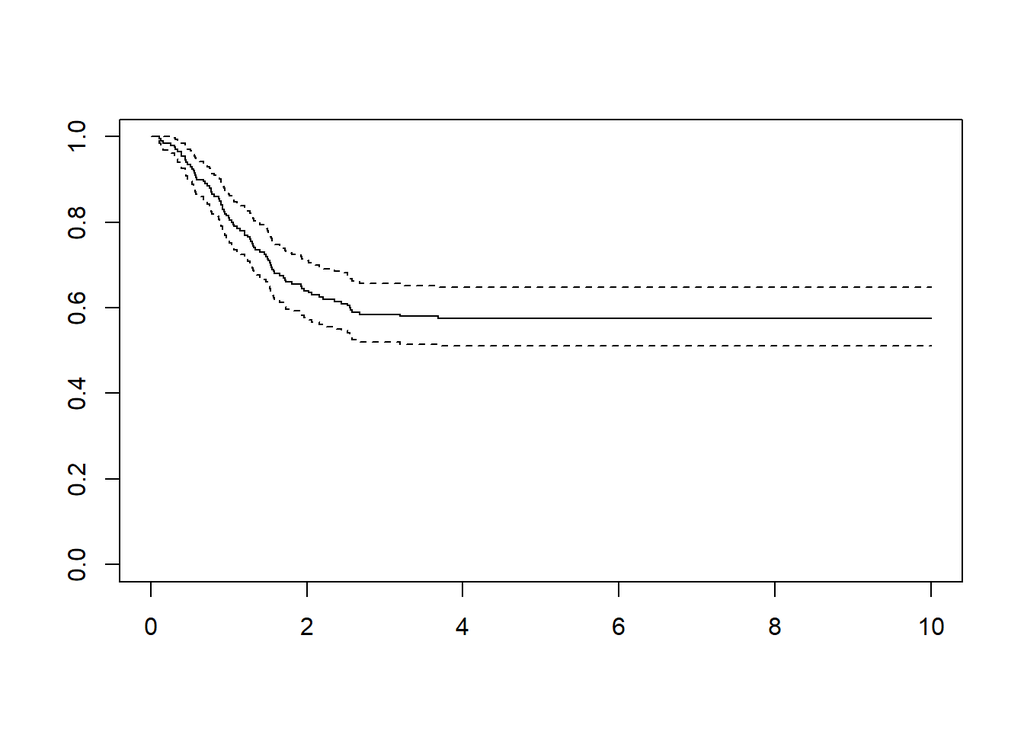

```r
plot(survfit(Surv(t, status) ~ 1, data=curedata))
```

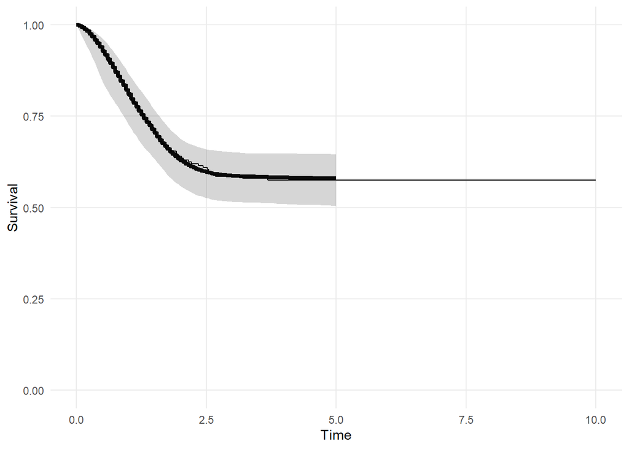

```r
noncure_mod <- survextrap(Surv(t, status) ~ 1, data=curedata, fit_method = "opt")
plot_survival(noncure_mod,tmax=5)
```

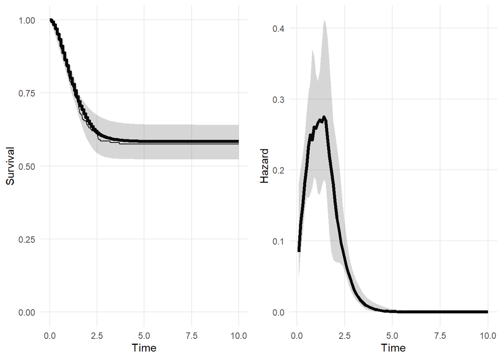

```r
cure_mod <- survextrap(Surv(t, status) ~ 1, data=curedata, cure=TRUE, iter=300, chains=1, loo=FALSE)
plot(cure_mod, tmax=10, niter=20)
```

Covariates on the cure fraction can be supplied by putting a formula in the `cure` argument. These will be modelled using logistic regression.

```r
curec_mod <- survextrap(Surv(t, status) ~ 1, data=curedata, cure=~x, fit_method="opt")
summary(curec_mod) %>%
    filter(variable %in% c("pcure", "logor_cure", "or_cure"))
```

```
## # A tibble: 3 × 10
##   variable   basis_num term   mode median lower upper     sd  rhat ess_bulk
##   <chr>          <dbl> <chr> <dbl>  <dbl> <dbl> <dbl>  <dbl> <dbl>    <dbl>
## 1 pcure             NA <NA>  0.481  0.480 0.383 0.579 0.0493 1.000    1962.
## 2 logor_cure        NA x     0.778  0.787 0.232 1.35  0.289  1.000    1925.
## 3 or_cure           NA x     2.18   2.20  1.26  3.85  0.673  1.000    1925.
```

In this summary, `pcure` is the probability of cure at a value of 0 for the covariate `x.`

## Additive hazards / relative survival models

To implement an “additive hazards” (“relative survival”) model (see the methods vignette), the background hazard can be supplied alongside the data. This can be done in two ways - note the meaning of the predictions from the model depends on which of these specifications was used.

### Background hazard defined at all times

The recommended way is to build a data frame that defines the value of the background hazard at all times. The hazard is assumed to be a piecewise-constant function. The data frame has columns `"hazard"` and `"time"`, and each row defines the value of the hazard between the current time and the next time. The first value of `"time"` should be 0, and the final row of the data defines the hazard for all times greater than the last time. For example:

```r
bh <- data.frame(time=c(0, 3, 5, 10),
                 hazard=c(0.01, 0.05, 0.1, 0.2))
```

When supplied to `survextrap`, this defines a full model for overall hazard at any time.

In the recurring example model, suppose we have external data about the background hazard that we use to extrapolate survival up to 15 years. This is represented in the data frame `bh` defined above.

The “cause-specific” hazard represents death from colon cancer, and the “background” hazard represents deaths from other causes. We suppose that colon cancer deaths dominate in the shorter term covered by the individual data (0-3 years), but the risk of death from other causes increases gradually after that.

We fit one model `mod` that excludes this information, and another model that includes it.

```r
mod <- survextrap(Surv(years, status) ~ 1, data=colons, fit_method="opt")
mod_bh <- survextrap(Surv(years, status) ~ 1, data=colons, fit_method="opt", backhaz=bh)
```

The posterior medians of the survival and hazard functions under `mod_bh` are overlaid on the posterior distributions from `mod`. The fitted survival and hazard in the short term agree under both models, but the survival is worse in the long term when the increase in the background hazard at times 3, 5 and 10 is accounted for.

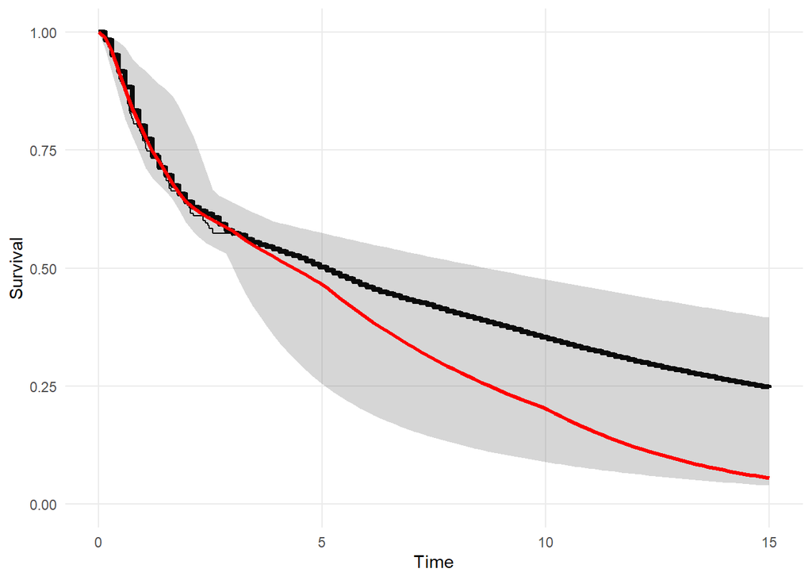

```r
plot_survival(mod, tmax=15, niter=20) +
  geom_line(data=survival(mod_bh, tmax=15, niter=20), aes(y=median, x=t), col="red", lwd=1.2)
```

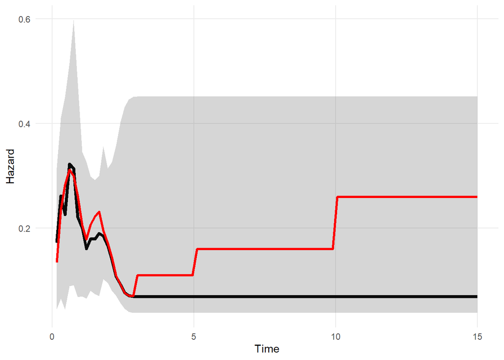

```r
plot_hazard(mod, tmax=15, niter=20) +
  geom_line(data=hazard(mod_bh, tmax=15, niter=20), aes(y=median, x=t), col="red", lwd=1.2)
```

Note that this kind of relative survival model can also be used together with a cure model. If both `cure` and `backhaz` are specified, then the cure model is assumed to apply to the cause-specific hazard. This will define a model where the cause-specific hazard approaches zero, hence the overall hazard is increasingly dominated by the background causes of death, as time increases.

### Stratified background hazards

Commonly, population mortality statistics are available by age and sex. If the same stratifying variables are recorded in the survival data (either the trial or external data) then `survextrap` allows the strata to be matched with the appropriate stratified background hazards.

A simple example is shown here. Suppose the following background hazard data are available, where people aged over 70 have 1.2 times the mortality rate of the under-70s. The year of age is recorded in the trial data `colons`, which we convert to an over/under 70 binary age group.

```r
bh_strata <- data.frame(time = rep(bh$time, 2),
                        hazard = c(bh$hazard, bh$hazard*1.2),
                        agegroup = rep(c("Under 70", "Over 70"),each=4))
colons$agegroup <- cut(colons$age, breaks=c(0,70,Inf),
                       right=FALSE, labels=c("Under 70","Over 70"))
bh_strata
```

```
##   time hazard agegroup
## 1    0  0.010 Under 70
## 2    3  0.050 Under 70
## 3    5  0.100 Under 70
## 4   10  0.200 Under 70
## 5    0  0.012  Over 70
## 6    3  0.060  Over 70
## 7    5  0.120  Over 70
## 8   10  0.240  Over 70
```

Then to run `survextrap` with a stratified background hazard, we indicate the names of the stratifying variables in the `backhaz_strata` argument. These variables must exist in both `data` and `backhaz` (and `external` if this is provided). Every row in `data` must have a row in `backhaz` with a matching stratum value. (Note there can be multiple stratifying variables, in which case we would specify, for example `backhaz_strata = c("agegroup","sex")`).

```r
mod_bhs <- survextrap(Surv(years, status) ~ 1, data=colons, fit_method="opt",
                      backhaz=bh_strata, backhaz_strata="agegroup")
```

To present predictions from a model with a stratified background hazard (e.g. RMST, hazard, survival), a `newdata` should be supplied to indicate which strata to present the results for, in the same manner as for models with covariates. Here the fitted hazard function reflects the increased long-term risk for over-70s.

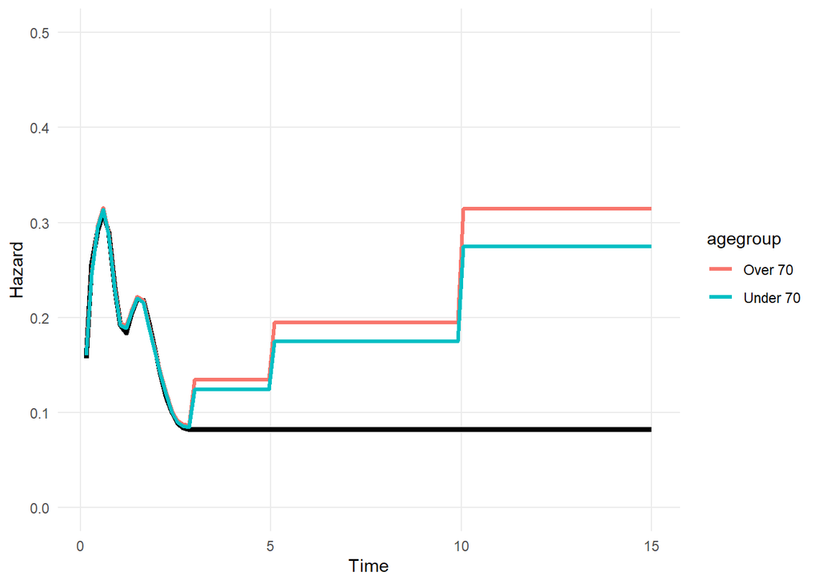

```r
nd <- data.frame(agegroup = c("Over 70", "Under 70"))
plot_hazard(mod, tmax=15, ci=FALSE) +
  geom_line(data = hazard(mod_bhs, newdata=nd, tmax=15, niter=300),
            aes(y=median, x=t, col=agegroup), lwd=1.2) +
  ylim(0,0.5)
```

### Background hazard only defined at the event times

An alternative approach is to supply the background hazard as an extra column alongside the data. The name of this column is supplied (unquoted) as the `backhaz` argument to `survextrap`. This relies on fewer assumptions about the background hazard, since only the hazard at the event times is used, and the background hazard outside the time spanned by the individual data is unspecified.

Here the background hazard at each event time is defined in an extra column `"bh"` in the individual data.

```r
colonsb <- colons
colonsb$bh <- rep(0.05, nrow(colons))
modb <- survextrap(Surv(years, status) ~ 1, data=colonsb, backhaz="bh", fit_method="opt")
```

As in the previous specification, the parameter estimates in the fitted model describe the excess or cause-specific hazard for the study population. However, the *predictions* from the model (e.g. fitted survival, hazard or mean survival) have a different meaning here. Previously they described the overall hazard - we were able to do this because we defined the hazard at all times. But now they describe the excess hazard for the study population - we cannot predict overall survival in general here, since we did not define the background hazard at all times.

In the example below, the excess hazard from the relative hazard model (with constant background 0.05) is shown in blue below the fitted overall hazard from a model with no background adjustment. As expected, the excess hazard is around 0.05 less than the overall hazard.

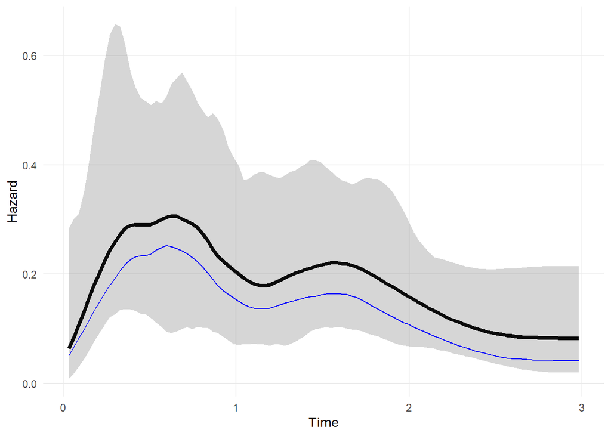

```r
mod <- survextrap(Surv(years, status) ~ 1, data=colonsb, fit_method="opt")
plot_hazard(mod) +
    geom_line(data=hazard(modb), col="blue")
```

### Comparison with other ways of supplying external data in survextrap

An alternative approach to modelling a study population and a background population in `survextrap` would be to estimate the background hazard from external aggregate data supplied as an `external` argument. A covariate would be included which takes a different value between the external data and the study data. By default, the hazards would then be assumed to be proportional between the study population and external population. Proportional hazards would be a restrictive assumption, however. The flexible nonproportional hazards model might be preferable.

The advantage of this alternative approach would be to account for uncertainty about the background hazard. If the background hazard is not uncertain, however, then the standard relative survival model would be adequate, as the excess hazard is modelled flexibly. In theory, another way to account for uncertainty in `backhaz` would be to place independent priors on each of the `backhaz` terms (without modelling `backhaz` as a parametric function of time) though this is not currently implemented.